# Homework_07

Madelynn Edwards

2024-02-28

# Creating Fake Data Sets to Explore Hypotheses

#### 1. Think about an ongoing study in your lab (or a paper you have read in a different class), and decide on a pattern that you might expect in your experiment if a specific hypothesis were true.

##### **Experiment:** How does earthworm invasion intensity affect soil insect richness?

Treatments: Control, Low, High (invasion intensity)

Variable: Insect abundance (# of insects present)

#### 2. To start simply, assume that the data in each of your treatment groups follow a normal distribution. Specify the sample sizes, means, and variances for each group that would be reasonable if your hypothesis were true. You may need to consult some previous literature and/or an expert in the field to come up with these numbers.

```r
my_data <- read.csv("insect_abundance_earthworm_invasion.csv",header=TRUE,sep=",")
str(my_data)
```

```
## 'data.frame':    30 obs. of  3 variables:
##  $ Control: int  74 50 69 45 56 49 35 57 78 80 ...
##  $ Low    : int  56 67 45 67 78 98 45 57 87 34 ...
##  $ High   : int  23 32 34 32 34 45 13 42 53 12 ...
```

```r
summary(my_data)
```

```
##     Control           Low             High
##  Min.   :35.00   Min.   :23.00   Min.   :10.00
##  1st Qu.:57.00   1st Qu.:34.50   1st Qu.:21.75
##  Median :68.00   Median :45.00   Median :32.00
##  Mean   :68.37   Mean   :51.15   Mean   :30.46
##  3rd Qu.:83.00   3rd Qu.:65.00   3rd Qu.:39.75
##  Max.   :97.00   Max.   :98.00   Max.   :53.00
##                  NA's   :3       NA's   :6
```

```r
var(my_data$Control)
```

```
## [1] 274.792
```

```r
var(my_data$Low, na.rm = TRUE)
```

```
## [1] 362.8234
```

```r
var(my_data$High, na.rm = TRUE)
```

```
## [1] 164.9547
```

```r
sd(my_data$Control)
```

```
## [1] 16.57685
```

```r
sd(my_data$Low, na.rm = TRUE)
```

```
## [1] 19.04792
```

```r
sd(my_data$High, na.rm = TRUE)
```

```
## [1] 12.84347
```

Control: Sample size = 30, Mean = 68.37, Variance = 274.792, SD = 16.57685

Low: Sample size = 27, Mean = 51.15, Variance = 362.8234, SD = 19.04792

#### 3. Using the methods we have covered in class, write code to create a random data set that has these attributes. Organize these data into a data frame with the appropriate structure.

```r
# creating data table
nGroup <- 3 # number of treatment groups
nName <- c("Control","Low", "High") # names of groups
nSize <- c(30,27,25) # number of observations in each group
nMean <- c(68.37,51.15,30.46) # mean of each group
nSD <- c(16.58,19.05,12.84) # standard deviation of each group


ID <- 1:(sum(nSize)) # id vector for each row
Abundance <- c(rnorm(n=nSize[1],mean=nMean[1],sd=nSD[1]),
            rnorm(n=nSize[2],mean=nMean[2],sd=nSD[2]),
            rnorm(n=nSize[3],mean=nMean[3],sd=nSD[3]))
Treatment <- rep(nName,nSize)
ANOdata <- data.frame(ID,Treatment,Abundance)
str(ANOdata)
```

```
## 'data.frame':    82 obs. of  3 variables:
##  $ ID       : int  1 2 3 4 5 6 7 8 9 10 ...
##  $ Treatment: chr  "Control" "Control" "Control" "Control" ...
##  $ Abundance: num  100.1 88.7 94.7 103 68.8 ...
```

```r
print(ANOdata)
```

```
##    ID Treatment Abundance
## 1   1   Control 100.08390
## 2   2   Control  88.74780
## 3   3   Control  94.71581
## 4   4   Control 103.00641
## 5   5   Control  68.77967
## 6   6   Control  89.55094
## 7   7   Control  57.49989
## 8   8   Control  69.15121
## 9   9   Control  74.32657
## 10 10   Control  45.99579
## 11 11   Control  83.62930
## 12 12   Control  93.95153
## 13 13   Control  42.68466
## 14 14   Control  61.47345
```

[output cut: 68 more lines]

#### 4. Now write code to analyze the data, probably as an ANOVA or regression analysis, but possibly as a logistic regression or contingency table analysis. Write code to generate a useful graph of the data.

Since I want to compare differences among three different variables, I will be using a one-way **ANOVA**. The independent variable (treatment) is discrete and the dependent variable (abundance) is continuous.

```r
library(tidyverse)
# Basic ANOVA in R
abundanceAOV <- aov(Abundance~Treatment,data=ANOdata)
print(abundanceAOV)
```

```
## Call:
##    aov(formula = Abundance ~ Treatment, data = ANOdata)
##
## Terms:
##                 Treatment Residuals
## Sum of Squares   20469.29  23117.55
## Deg. of Freedom         2        79
##
## Residual standard error: 17.10635
## Estimated effects may be unbalanced
```

```r
print(summary(abundanceAOV))
```

```
##             Df Sum Sq Mean Sq F value   Pr(>F)
## Treatment    2  20469   10235   34.98 1.32e-11 ***
## Residuals   79  23118     293
## ---
## Signif. codes:  0 '***' 0.001 '**' 0.01 '*' 0.05 '.' 0.1 ' ' 1
```

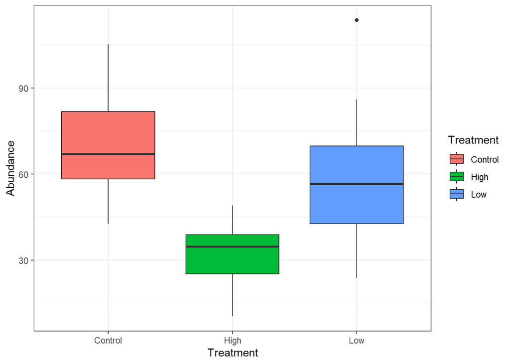

```r
# graph for ANOVA
ANOPlot <- ggplot(data=ANOdata,aes(x=Treatment,y=Abundance,fill=Treatment)) +
  geom_boxplot()+
  theme_bw()
print(ANOPlot)
```

#### 5. Try running your analysis multiple times to get a feeling for how variable the results are with the same parameters, but different sets of random numbers.

Rerunning the code from questions 3 and 4 provides a different, but similar conclusion every time. There is variability within the dataset and the boxplots in the graph are different size, but there is always a significant difference among treatment.

#### 6. Now begin adjusting the means of the different groups. Given the sample sizes you have chosen, how small can the differences between the groups be (the “effect size”) for you to still detect a significant pattern (p < 0.05)?

```r
# creating data table with new/adjusted means
nGroup <- 3 # number of treatment groups
nName <- c("Control","Low", "High") # names of groups
nSize <- c(30,27,25) # number of observations in each group
nMean <- c(50,45,39) # mean of each group
nSD <- c(16.58,19.05,12.84) # standard deviation of each group


ID <- 1:(sum(nSize)) # id vector for each row
Abundance <- c(rnorm(n=nSize[1],mean=nMean[1],sd=nSD[1]),
            rnorm(n=nSize[2],mean=nMean[2],sd=nSD[2]),
            rnorm(n=nSize[3],mean=nMean[3],sd=nSD[3]))
Treatment <- rep(nName,nSize)
ANOdata_adjmeans <- data.frame(ID,Treatment,Abundance)
str(ANOdata_adjmeans)
```

```
## 'data.frame':    82 obs. of  3 variables:
##  $ ID       : int  1 2 3 4 5 6 7 8 9 10 ...
##  $ Treatment: chr  "Control" "Control" "Control" "Control" ...
##  $ Abundance: num  10.1 55.9 61.8 54.6 61.7 ...
```

```r
print(ANOdata_adjmeans)
```

```
##    ID Treatment Abundance
## 1   1   Control 10.126942
## 2   2   Control 55.886228
## 3   3   Control 61.793226
## 4   4   Control 54.556022
## 5   5   Control 61.739301
## 6   6   Control 48.730382
## 7   7   Control 56.598829
## 8   8   Control 87.348901
## 9   9   Control 35.283963
## 10 10   Control 64.971768
## 11 11   Control 55.978959
## 12 12   Control 47.357390
## 13 13   Control 66.314794
## 14 14   Control 47.172185
```

[output cut: 68 more lines]

```r
# ANOVA results for adjusted data
abundanceAOV_adjmeans <- aov(Abundance~Treatment,data=ANOdata_adjmeans)
print(abundanceAOV_adjmeans)
```

```
## Call:
##    aov(formula = Abundance ~ Treatment, data = ANOdata_adjmeans)
##
## Terms:
##                 Treatment Residuals
## Sum of Squares    1798.48  18760.03
## Deg. of Freedom         2        79
##
## Residual standard error: 15.41002
## Estimated effects may be unbalanced
```

```r
print(summary(abundanceAOV_adjmeans))
```

```
##             Df Sum Sq Mean Sq F value Pr(>F)
## Treatment    2   1798   899.2   3.787 0.0269 *
## Residuals   79  18760   237.5
## ---
## Signif. codes:  0 '***' 0.001 '**' 0.01 '*' 0.05 '.' 0.1 ' ' 1
```

The original means were: Control: 68.37, Low: 51.15, High: 30.46 (*** significance).

When I adjusted them to be Control: 50, Low: 45, High: 40, the results were not significant. I then adjusted them again at Control: 50, Low: 45, High: 39 and the results showed significance (*significance). Compared to the original means, the new means are much closer together while still being able to detect significance.

#### 7. Alternatively, for the effect sizes you originally hypothesized, what is the minimum sample size you would need in order to detect a statistically significant effect? Again, run the model a few times with the same parameter set to get a feeling for the effect of random variation in the data.

```r
# creating new dataset with smaller sample size
nGroup <- 3 # number of treatment groups
nName <- c("Control","Low", "High") # names of groups
nSize <- c(5,5,5) # number of observations in each group
nMean <- c(68.37,51.15,30.46) # mean of each group
nSD <- c(16.58,19.05,12.84) # standard deviation of each group


ID <- 1:(sum(nSize)) # id vector for each row
Abundance <- c(rnorm(n=nSize[1],mean=nMean[1],sd=nSD[1]),
            rnorm(n=nSize[2],mean=nMean[2],sd=nSD[2]),
            rnorm(n=nSize[3],mean=nMean[3],sd=nSD[3]))
Treatment <- rep(nName,nSize)
ANOdata_adjss <- data.frame(ID,Treatment,Abundance)
str(ANOdata_adjss)
```

```
## 'data.frame':    15 obs. of  3 variables:
##  $ ID       : int  1 2 3 4 5 6 7 8 9 10 ...
##  $ Treatment: chr  "Control" "Control" "Control" "Control" ...
##  $ Abundance: num  62.1 56.3 79.2 64.3 52.7 ...
```

```r
print(ANOdata_adjss)
```

```
##    ID Treatment Abundance
## 1   1   Control  62.06732
## 2   2   Control  56.32211
## 3   3   Control  79.24600
## 4   4   Control  64.26977
## 5   5   Control  52.68688
## 6   6       Low  55.53522
## 7   7       Low  78.41318
## 8   8       Low  34.41172
## 9   9       Low  65.51155
## 10 10       Low  52.82815
## 11 11      High  31.91117
## 12 12      High  32.27341
## 13 13      High  26.81920
## 14 14      High  39.74430
## 15 15      High  53.04779
```

```r
# ANOVA results for adjusted sample size data
abundanceAOV_adjss <- aov(Abundance~Treatment,data=ANOdata_adjss)
print(abundanceAOV_adjss)
```

```
## Call:
##    aov(formula = Abundance ~ Treatment, data = ANOdata_adjss)
##
## Terms:
##                 Treatment Residuals
## Sum of Squares   1898.323  1894.167
## Deg. of Freedom         2        12
##
## Residual standard error: 12.56373
## Estimated effects may be unbalanced
```

```r
print(summary(abundanceAOV_adjss))
```

```
##             Df Sum Sq Mean Sq F value Pr(>F)
## Treatment    2   1898   949.2   6.013 0.0155 *
## Residuals   12   1894   157.8
## ---
## Signif. codes:  0 '***' 0.001 '**' 0.01 '*' 0.05 '.' 0.1 ' ' 1
```

First, I made all treatments have equal sample size at n=25 (sig diff detected).

All sample size n=20, still sig diff.

All sample size n=15, still sig diff.

All sample size n=10, still sig diff.

All sample size n=5, still sig diff. **this is the smallest sample size to produce a statistical difference**

All sample size n=3, no sig diff.

All sample size n=4, no sig diff.